# Regresión Lineal Simple

willandru

2022-10-20

# DATA SET: “COSTO SALUD”

El dataset fue extraido de *Kaggle*: https://www.kaggle.com/datasets/mirichoi0218/insurance

*COLUMNAS*

- **edad**: Edad del beneficiario principal
- **sexo**: Género femenino o masculino
- **bmi**: Índice de masa corporal, que proporciona una comprensión del peso relativamente alto o bajo en relación con la altura, idealmente 18,5 a 24,9.
- **niños**: Número de niños cubiertos por el seguro de salud / Número de dependientes
- **fumador**: Fuma o no fuma
- **región**: el área residencial del beneficiario en los EE. UU., noreste, sureste, suroeste, noroeste.
- **cargos**: costos médicos individuales facturados por el seguro de salud

## Cargar Librerías

```r
library('GGally')
library('dplyr')
library('lmtest')
```

## Información de los Datos

```r
df <- read.csv('insurance.csv')
head(df)
```

```
##   age    sex    bmi children smoker    region   charges
## 1  19 female 27.900        0    yes southwest 16884.924
## 2  18   male 33.770        1     no southeast  1725.552
## 3  28   male 33.000        3     no southeast  4449.462
## 4  33   male 22.705        0     no northwest 21984.471
## 5  32   male 28.880        0     no northwest  3866.855
## 6  31 female 25.740        0     no southeast  3756.622
```

A continuación vemos los tipos de datos y el tamaño del dataframe :

```r
str(df)
```

```
## 'data.frame':    1338 obs. of  7 variables:
##  $ age     : int  19 18 28 33 32 31 46 37 37 60 ...
##  $ sex     : chr  "female" "male" "male" "male" ...
##  $ bmi     : num  27.9 33.8 33 22.7 28.9 ...
##  $ children: int  0 1 3 0 0 0 1 3 2 0 ...
##  $ smoker  : chr  "yes" "no" "no" "no" ...
##  $ region  : chr  "southwest" "southeast" "southeast" "northwest" ...
##  $ charges : num  16885 1726 4449 21984 3867 ...
```

```r
summary(df)
```

```
##       age            sex                 bmi           children
##  Min.   :18.00   Length:1338        Min.   :15.96   Min.   :0.000
##  1st Qu.:27.00   Class :character   1st Qu.:26.30   1st Qu.:0.000
##  Median :39.00   Mode  :character   Median :30.40   Median :1.000
##  Mean   :39.21                      Mean   :30.66   Mean   :1.095
##  3rd Qu.:51.00                      3rd Qu.:34.69   3rd Qu.:2.000
##  Max.   :64.00                      Max.   :53.13   Max.   :5.000
##     smoker             region             charges
##  Length:1338        Length:1338        Min.   : 1122
##  Class :character   Class :character   1st Qu.: 4740
##  Mode  :character   Mode  :character   Median : 9382
##                                        Mean   :13270
##                                        3rd Qu.:16640
##                                        Max.   :63770
```

## Gráfica de Dispersión

Utilizando la función nativa *plot* de R podemos visualizar un diagrama de dispersión para todas las variables del dataframe:

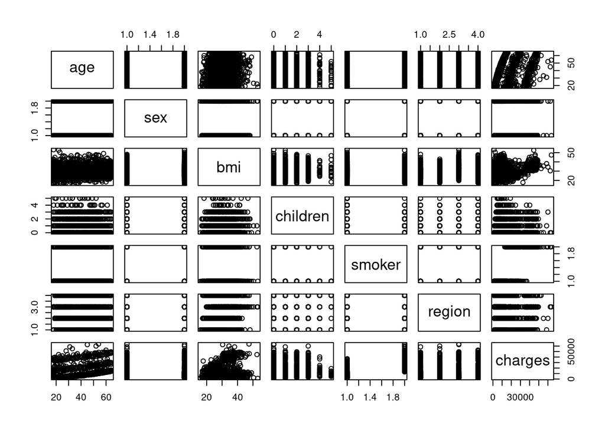

```r
plot(df)
```

Del anterior gráfico podemos ver que hay una relación lineal subdividida en tres grupos para las variables *edad* y *costo de salud*, si pudieramos determinar porque estan ocurriendo estos grupos podríamos crear una relación lineal entre estas 2 variables para los subgrupos.

## Visualizamos la relación lineal y los 3 subgrupos que aparecen entre la EDAD y el COSTO

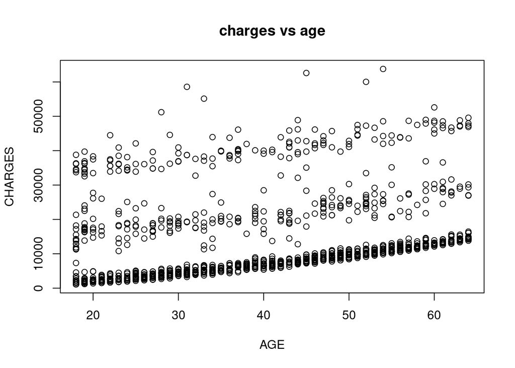

```r
plot(x = df$age, y=df$charges, xlab = 'AGE', ylab = 'CHARGES', main = 'charges vs age')
```

## Visualizamos la distribución, la dispersión y los coeficientes de relación de los datos por colores según el sexo de la población

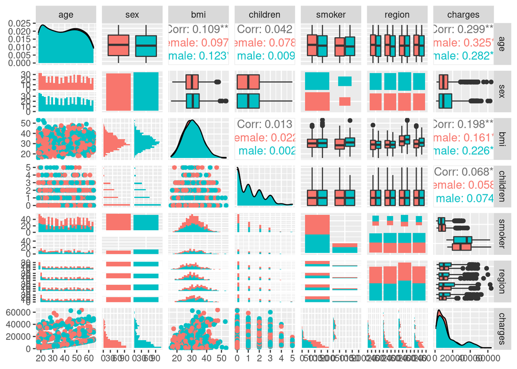

```r
ggpairs(df, columns=1:7, ggplot2::aes(colour=sex), progress = FALSE)
```

Podemos ver que tenemos unos coeficientes de relación de 0.2 y además vemos que la gráfica de *edad* vs *costo* no puede ser explicada por 1 solo modelo lineal.

## Distribución, Dispersión y Coeficientes de relación de los datos por colores según ‘fumadores’ en la población

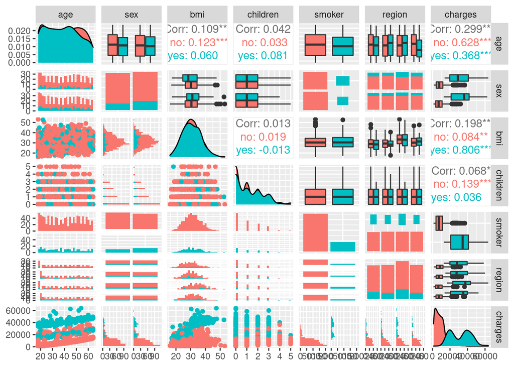

```r
ggpairs(df, columns=1:7, ggplot2::aes(colour=smoker), progress = FALSE)
```

#### Relación lineal aparente de los 2 subgrupos que aparecen entre BMI y el COSTO

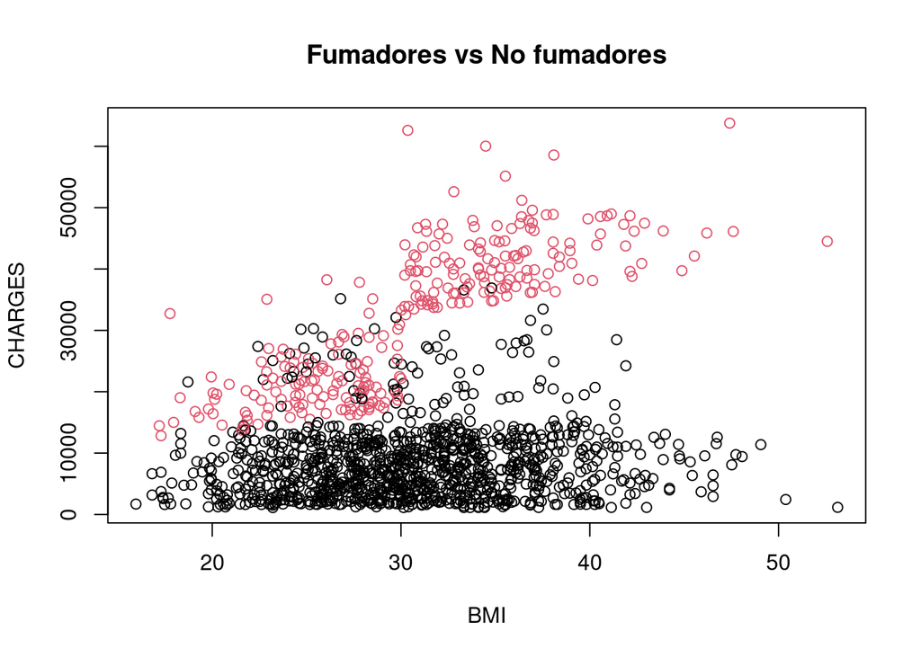

```r
plot(x = df$bmi, y=df$charges,  col = factor(df$smoker), main = 'Fumadores vs No fumadores', xlab = 'BMI', ylab = 'CHARGES')
```

Aquí podemos observar varias cosas útiles: - Existe una correlación muy alta para los ‘smoker=yes’ de 0.8 con respecto al ‘bmi’ - Existe una correlación de 0.6 para los ‘smokers=no’ con respecto a la edad

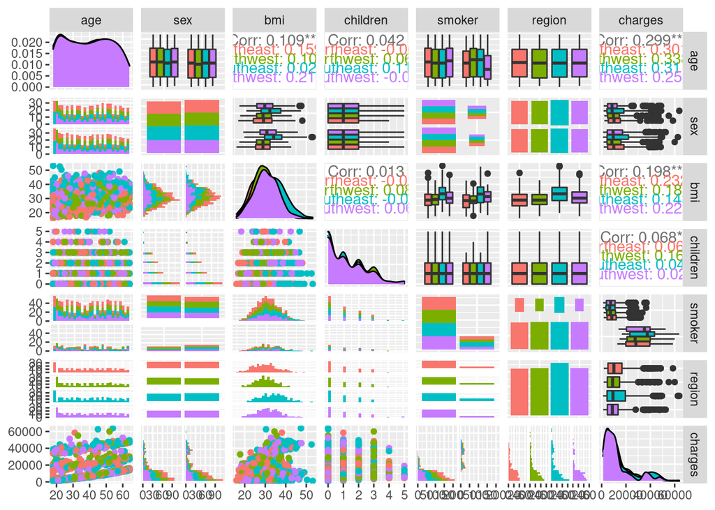

```r
ggpairs(df, columns=1:7, ggplot2::aes(colour=as.factor(region)), progress = FALSE)
```

No encontramos mejores relaciones visualizando los datos según la ‘región’. No pudimos encontrar la razón de los 3 subgrupos del diagrama de dispersión *edad vs costo* así que decidímos realizar el análisis para los NO FUMADORES y aparte para los SI FUMADORES, de esta manera podremos explicar la variable ‘costo’ utilizando la variable más correlacionada en cada caso, que como se observo anteriormete es la *edad* para los no fumadores y el indice *bmi* para los fumadores.

## Creamos un dataset para los fumadores y no fumadores

```r
non<- select(filter(df, smoker == 'no'),c(age,sex,bmi, children, smoker, region, charges))
yes<- select(filter(df, smoker == 'yes'),c(age,sex,bmi, children, smoker, region, charges))
```

### Observamos correlación de 0.6 entre ‘edad’ vs ‘costo’ para los NO FUMADORES

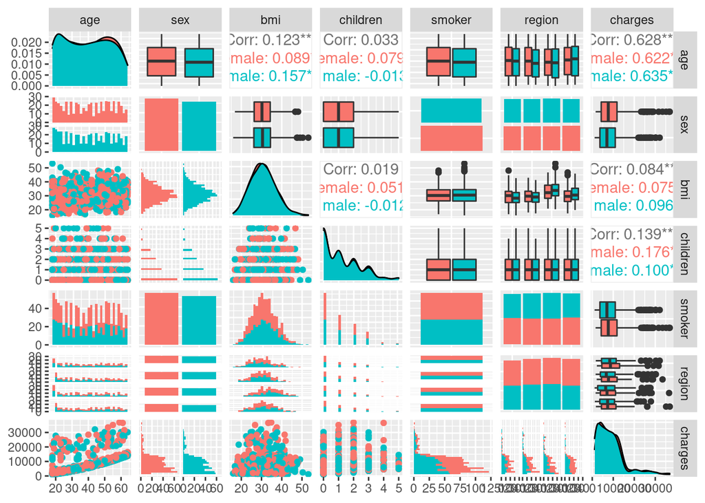

```r
ggpairs(non, columns=1:7, ggplot2::aes(colour=as.factor(sex)), progress = FALSE)
```

### Observamos correlación de 0.8 entre ‘bmi’ vs ‘costo’ para los FUMADORES

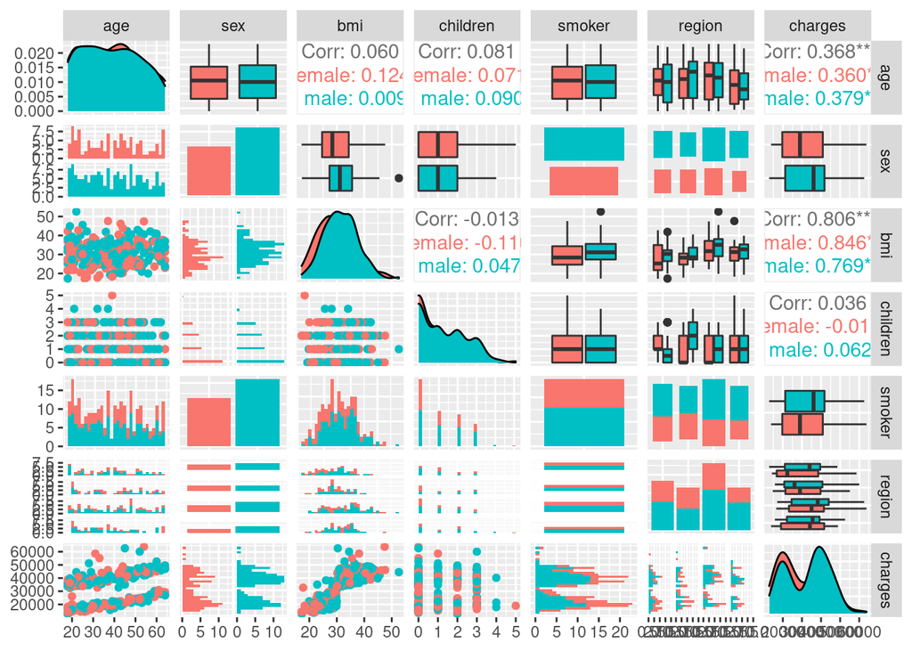

```r
ggpairs(yes, columns=1:7, ggplot2::aes(colour=as.factor(sex)), progress = FALSE)
```

# MODELOS REGRESIÓN LINEAL

## CREANDO LOS MODELOS DE REGRESIÓN LINEAL : 1 PARA FUMADORES Y OTRO PARA NO FUMADORES

Los siguientes modelos buscan explicar el ‘costo de salud’ para personas fumadoras y no fumadoras, ya que se encontro que esta es la variable más correlacionada con el ‘costo’. Además se hará un modelo de regresión lineal para los no fumadores basandose en la ‘edad’ , mientras que para los fumadores utilizaremos el índece de ‘bmi’ de las personas para predecir el costo de salud.

## NO FUMADORES: COSTO vs EDAD

```r
lm1 <- lm(non$charges~non$age)
summary(lm1)
```

```
##
## Call:
## lm(formula = non$charges ~ non$age)
##
## Residuals:
##     Min      1Q  Median      3Q     Max
## -3182.9 -1948.6 -1363.8  -665.2 24470.7
##
## Coefficients:
##             Estimate Std. Error t value Pr(>|t|)
## (Intercept) -2091.42     425.10   -4.92    1e-06 ***
## non$age       267.25      10.16   26.29   <2e-16 ***
## ---
## Signif. codes:  0 '***' 0.001 '**' 0.01 '*' 0.05 '.' 0.1 ' ' 1
##
## Residual standard error: 4667 on 1062 degrees of freedom
## Multiple R-squared:  0.3943, Adjusted R-squared:  0.3937
## F-statistic: 691.4 on 1 and 1062 DF,  p-value: < 2.2e-16
```

### Verificamos los supuestos del modelo: Normalidad de residuiales y Homogeneidad de varianza

### Test de Normalidad sobre los residuales:

Ho: Los errores son Normales Ha: Los errores No son Normales p-value <0.05 se rechaza la Ho

```r
l1res<- residuals(lm1)
shapiro.test(l1res)
```

```
##
##  Shapiro-Wilk normality test
##
## data:  l1res
## W = 0.49487, p-value < 2.2e-16
```

Los residuales NO pasa la prueba de NORMALIDAD para este modelo